# AIML_ML_Project_full_code_notebook

## Problem Statement

### Context

AllLife Bank is a US bank that has a growing customer base. The majority of these customers are liability customers (depositors) with varying sizes of deposits. The number of customers who are also borrowers (asset customers) is quite small, and the bank is interested in expanding this base rapidly to bring in more loan business and in the process, earn more through the interest on loans. In particular, the management wants to explore ways of converting its liability customers to personal loan customers (while retaining them as depositors).

A campaign that the bank ran last year for liability customers showed a healthy conversion rate of over 9% success. This has encouraged the retail marketing department to devise campaigns with better target marketing to increase the success ratio.

You as a Data scientist at AllLife bank have to build a model that will help the marketing department to identify the potential customers who have a higher probability of purchasing the loan.

### Objective

To predict whether a liability customer will buy personal loans, to understand which customer attributes are most significant in driving purchases, and identify which segment of customers to target more.

### Data Dictionary

- `ID`: Customer ID
- `Age`: Customer’s age in completed years
- `Experience`: #years of professional experience
- `Income`: Annual income of the customer (in thousand dollars)
- `ZIP Code`: Home Address ZIP code.
- `Family`: the Family size of the customer
- `CCAvg`: Average spending on credit cards per month (in thousand dollars)
- `Education`: Education Level. 1: Undergrad; 2: Graduate;3: Advanced/Professional
- `Mortgage`: Value of house mortgage if any. (in thousand dollars)
- `Personal_Loan`: Did this customer accept the personal loan offered in the last campaign? (0: No, 1: Yes)
- `Securities_Account`: Does the customer have securities account with the bank? (0: No, 1: Yes)
- `CD_Account`: Does the customer have a certificate of deposit (CD) account with the bank? (0: No, 1: Yes)
- `Online`: Do customers use internet banking facilities? (0: No, 1: Yes)
- `CreditCard`: Does the customer use a credit card issued by any other Bank (excluding All life Bank)? (0: No, 1: Yes)

## Importing necessary libraries

```python
# Installing the libraries with the specified version.
!pip install numpy==1.25.2 pandas==1.5.3 matplotlib==3.7.1 seaborn==0.13.1 scikit-learn==1.2.2 sklearn-pandas==2.2.0 -q --user
```

**Note**:

1. After running the above cell, kindly restart the notebook kernel (for Jupyter Notebook) or runtime (for Google Colab), write the relevant code for the project from the next cell, and run all cells sequentially from the next cell.
2. On executing the above line of code, you might see a warning regarding package dependencies. This error message can be ignored as the above code ensures that all necessary libraries and their dependencies are maintained to successfully execute the code in this notebook.

## Loading the dataset

```python
import pandas as pd

df = pd.read_csv("Loan_Modelling.csv")
```

## Data Overview

- Observations
- Sanity checks

```python
df.head() # Viewing the first few rows of the dataset
```

|  | ID | Age | Experience | Income | ZIPCode | Family | CCAvg | Education | Mortgage | Personal_Loan | Securities_Account | CD_Account | Online | CreditCard |
| --- | --- | --- | --- | --- | --- | --- | --- | --- | --- | --- | --- | --- | --- | --- |
| 0 | 1 | 25 | 1 | 49 | 91107 | 4 | 1.6 | 1 | 0 | 0 | 1 | 0 | 0 | 0 |
| 1 | 2 | 45 | 19 | 34 | 90089 | 3 | 1.5 | 1 | 0 | 0 | 1 | 0 | 0 | 0 |
| 2 | 3 | 39 | 15 | 11 | 94720 | 1 | 1.0 | 1 | 0 | 0 | 0 | 0 | 0 | 0 |
| 3 | 4 | 35 | 9 | 100 | 94112 | 1 | 2.7 | 2 | 0 | 0 | 0 | 0 | 0 | 0 |
| 4 | 5 | 35 | 8 | 45 | 91330 | 4 | 1.0 | 2 | 0 | 0 | 0 | 0 | 0 | 1 |

```python
df.info() # Getting an understanding of the basic structure of the dataset
```

```
<class 'pandas.core.frame.DataFrame'>
RangeIndex: 5000 entries, 0 to 4999
Data columns (total 14 columns):
 #   Column              Non-Null Count  Dtype
---  ------              --------------  -----
 0   ID                  5000 non-null   int64
 1   Age                 5000 non-null   int64
 2   Experience          5000 non-null   int64
 3   Income              5000 non-null   int64
 4   ZIPCode             5000 non-null   int64
 5   Family              5000 non-null   int64
 6   CCAvg               5000 non-null   float64
 7   Education           5000 non-null   int64
 8   Mortgage            5000 non-null   int64
 9   Personal_Loan       5000 non-null   int64
 10  Securities_Account  5000 non-null   int64
 11  CD_Account          5000 non-null   int64
 12  Online              5000 non-null   int64
 13  CreditCard          5000 non-null   int64
dtypes: float64(1), int64(13)
memory usage: 547.0 KB
```

```python
print(df.isnull().sum()) # Checking if there are any missing values in the dataset
```

```
ID                    0
Age                   0
Experience            0
Income                0
ZIPCode               0
Family                0
CCAvg                 0
Education             0
Mortgage              0
Personal_Loan         0
Securities_Account    0
CD_Account            0
Online                0
CreditCard            0
dtype: int64
```

```python
print(df['ID'].nunique() == df.shape[0]) # Checking if the ID column is unique for each row
```

```
True
```

```python
print(df['Personal_Loan'].value_counts()) # Checking the distribution of the target variable
```

```
0    4520
1     480
Name: Personal_Loan, dtype: int64
```

```python
print(df['Education'].unique())
print(df['Family'].unique())
print(df['CD_Account'].unique())
```

```
[1 2 3]
[4 3 1 2]
[0 1]
```

## Exploratory Data Analysis.

- EDA is an important part of any project involving data.
- It is important to investigate and understand the data better before building a model with it.
- A few questions have been mentioned below which will help you approach the analysis in the right manner and generate insights from the data.
- A thorough analysis of the data, in addition to the questions mentioned below, should be done.

**Questions**:

1. What is the distribution of mortgage attribute? Are there any noticeable patterns or outliers in the distribution?
2. How many customers have credit cards?
3. What are the attributes that have a strong correlation with the target attribute (personal loan)?
4. How does a customer's interest in purchasing a loan vary with their age?
5. How does a customer's interest in purchasing a loan vary with their education?

```python
# 1. What is the distribution of mortgage attribute? Are there any noticeable patterns or outliers in the distribution?

print(df['Mortgage'].describe())
```

```
count    5000.000000
mean       56.498800
std       101.713802
min         0.000000
25%         0.000000
50%         0.000000
75%       101.000000
max       635.000000
Name: Mortgage, dtype: float64
```

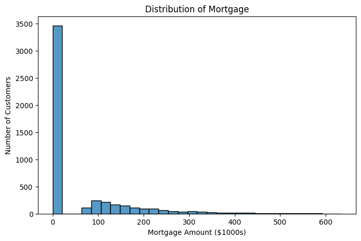

```python
import seaborn as sns
import matplotlib.pyplot as plt

plt.figure(figsize=(8,5))
sns.histplot(df['Mortgage'], bins=30)
plt.title('Distribution of Mortgage')
plt.xlabel('Mortgage Amount ($1000s)')
plt.ylabel('Number of Customers')
plt.show()
```

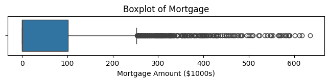

```python
plt.figure(figsize=(8,1))
sns.boxplot(x=df['Mortgage'])
plt.title('Boxplot of Mortgage')
plt.xlabel('Mortgage Amount ($1000s)')
plt.show()
```

### Observations

- Over 50% of customers have no mortgage, as the median is 0.
- The distribution is heavily right-skewed, with most values clustered at lower amounts.
- A significant number of outliers exist beyond $250k, going up to $635k.

```python
# How many customers have credit cards?
df['CreditCard'].value_counts()
```

```
0    3530
1    1470
Name: CreditCard, dtype: int64
```

```python
# To see the percentage of customers with credit cards, who accepted personal loans
loan_takers = df[df['Personal_Loan'] == 1]
cc_among_loan_takers = loan_takers['CreditCard'].value_counts(normalize=True) * 100
print(cc_among_loan_takers)
```

```
0    70.208333
1    29.791667
Name: CreditCard, dtype: float64
```

```python
pd.crosstab(df['CreditCard'], df['Personal_Loan'], normalize='index') * 100
```

| Personal_Loan CreditCard | 0 | 1 |
| --- | --- | --- |
| 0 | 90.453258 | 9.546742 |
| 1 | 90.272109 | 9.727891 |

### Observation:

- 1470 customers had a credit card, as compared to the 3530 who didn't have one.
- Around 9.7% of credit card holders accepted the personal loan, similar to 9.5% of non-holders.
- Credit card ownership does not significantly influence personal loan acceptance.

```python
# 3. What are the attributes that have a strong correlation with the target attribute (personal loan)?
correlation_matrix = df.corr()
```

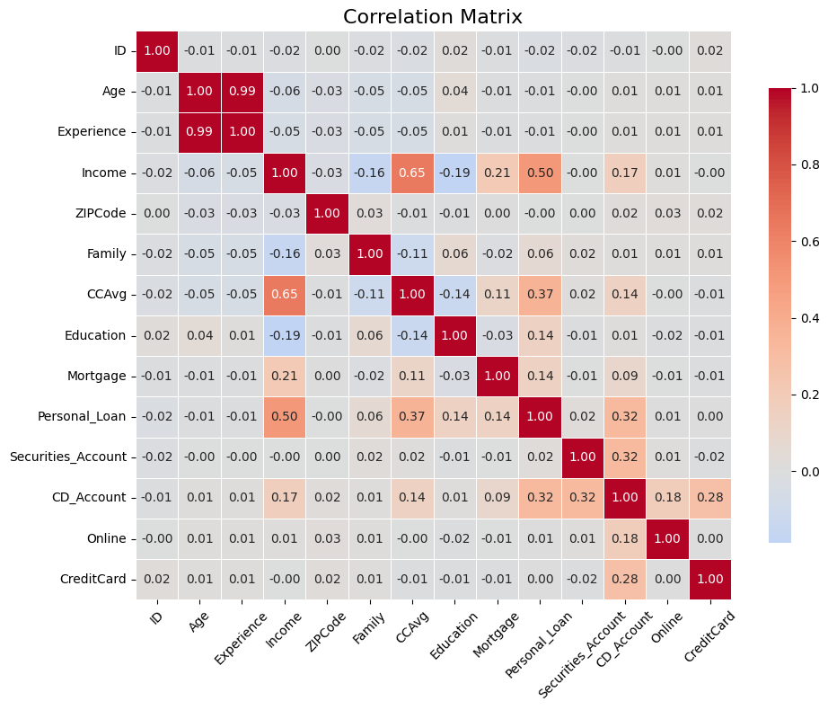

```python
plt.figure(figsize=(10, 8))
sns.heatmap(correlation_matrix, annot=True, cmap="coolwarm", center=0, linewidths=0.5, fmt=".2f", cbar_kws={"shrink": 0.8})
plt.title("Correlation Matrix", fontsize=16)
plt.xticks(rotation=45)
plt.tight_layout()
plt.show()
```

### Observations:

- The correlation matrix shows that `Income`, `CCAvg`, and `CD_Account` have the strongest positive correlations with `Personal_Loan`.
- `Education` and `Mortgage` also seem to have a moderate positive correlation with `Personal_Loan`.
- Other attributes however show little to no correlation with the target variable.

```python
# 4. How does a customer's interest in purchasing a loan vary with their age?
```

```python
bins = [20, 30, 40, 50, 60, 70, 80]
labels = ['20-30', '30-40', '40-50', '50-60', '60-70', '70-80']
df['Age Group'] = pd.cut(df['Age'], bins=bins, labels=labels, right=False)

loan_by_age = df.groupby('Age Group')['Personal_Loan'].mean() * 100
print(loan_by_age)
```

```
Age Group
20-30    10.040984
30-40    10.184443
40-50     9.307876
50-60     8.845577
60-70    10.237389
70-80          NaN
Name: Personal_Loan, dtype: float64
```

### Observations

- The trend of loan acceptance is fairly consistent across age groups, however there's a slight dip in the ranges of 50-60
- The correlation matrix also shows that age has almost no correlation with personal loan acceptance.

```python
# 4. How does a customer's interest in purchasing a loan vary with their age?
education_loan = df.groupby('Education')['Personal_Loan'].mean() * 100
print(education_loan)
```

```
Education
1     4.437023
2    12.972202
3    13.657562
Name: Personal_Loan, dtype: float64
```

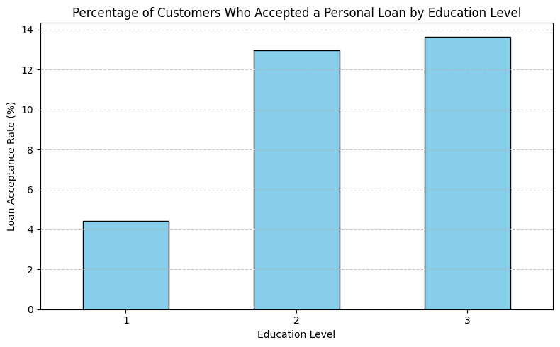

```python
education_loan_pct = df.groupby('Education')['Personal_Loan'].mean() * 100

plt.figure(figsize=(8, 5))
education_loan_pct.plot(kind='bar', color='skyblue', edgecolor='black')

plt.title('Percentage of Customers Who Accepted a Personal Loan by Education Level')
plt.xlabel('Education Level')
plt.ylabel('Loan Acceptance Rate (%)')
plt.xticks(rotation=0)
plt.grid(axis='y', linestyle='--', alpha=0.7)

plt.tight_layout()
plt.show()
```

### Observations:

- Customers with education level 1 are the least likely to accept loans, with only 4.4% acceptance rate.
- Education level 2 has a 12.97% acceptance rate, while level 3 has the highest at 13.65%.
- The trend suggests that higher education levels correlate with higher loan acceptance rates.
- The correlation matrix also shows a positive correlation between education level and personal loan acceptance.

## Univariate Analysis

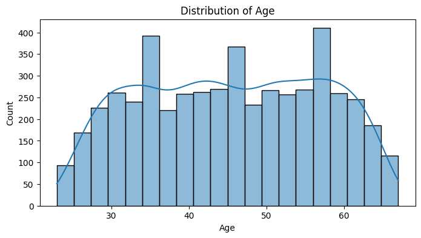

```python
# Age
plt.figure(figsize=(8,4))
sns.histplot(df['Age'], bins=20, kde=True)
plt.title("Distribution of Age")
plt.xlabel("Age")
plt.ylabel("Count")
plt.show()
```

#### Observations:

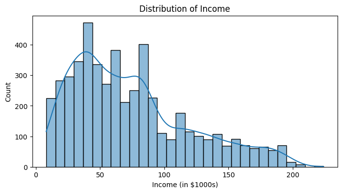

```python
plt.figure(figsize=(8,4))
sns.histplot(df['Income'], bins=30, kde=True)
plt.title("Distribution of Income")
plt.xlabel("Income (in $1000s)")
plt.ylabel("Count")
plt.show()
```

### Observations:

- Majority of customers have an income below $100k.
- There are some high income outlies with incomes above $200k, they may effect the analysis.

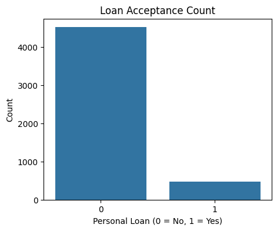

```python
plt.figure(figsize=(5,4))
sns.countplot(x='Personal_Loan', data=df)
plt.title("Loan Acceptance Count")
plt.xlabel("Personal Loan (0 = No, 1 = Yes)")
plt.ylabel("Count")
plt.show()
```

```python
accepted_percent = df['Personal_Loan'].mean() * 100
print(f"{accepted_percent:.2f}% of customers accepted the personal loan.")
```

```
9.60% of customers accepted the personal loan.
```

# Observations:

- Only a small percentage of customers (9.6%) accepted the personal loan.
- THe dataset is kinda imbalanced, with more customers not accepting the loan than those who did.

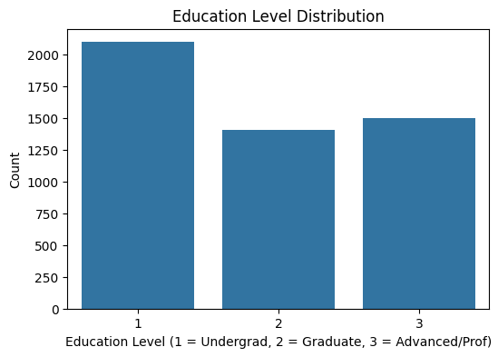

```python
# Education Level
plt.figure(figsize=(6,4))
sns.countplot(x='Education', data=df)
plt.title("Education Level Distribution")
plt.xlabel("Education Level (1 = Undergrad, 2 = Graduate, 3 = Advanced/Prof)")
plt.ylabel("Count")
plt.show()
```

# Obbservations:

- The education level distribution shows that most customers have an undergraduate degree (level 1), however there is a fair representation of graduate (level 2) and advanced/professional (level 3) degrees as well.
- The distribution is fairly balanced across the three education levels, with level 1 being the most

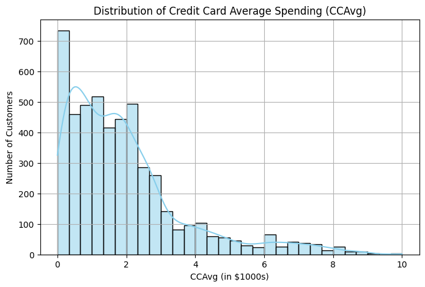

```python
# CC Avg
plt.figure(figsize=(8, 5))
sns.histplot(df['CCAvg'], bins=30, kde=True, color='skyblue')
plt.title('Distribution of Credit Card Average Spending (CCAvg)')
plt.xlabel('CCAvg (in $1000s)')
plt.ylabel('Number of Customers')
plt.grid(True)
plt.show()
```

## Bivariate Analysis

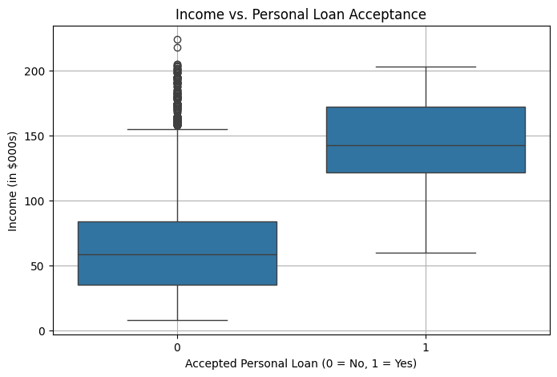

```python
plt.figure(figsize=(8, 5))
sns.boxplot(x='Personal_Loan', y='Income', data=df)
plt.title('Income vs. Personal Loan Acceptance')
plt.xlabel('Accepted Personal Loan (0 = No, 1 = Yes)')
plt.ylabel('Income (in $000s)')
plt.grid(True)
plt.show()
```

### Observations:

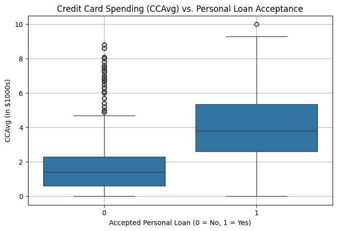

```python
# Personal Loan vs. CCAvg
plt.figure(figsize=(8, 5))
sns.boxplot(x='Personal_Loan', y='CCAvg', data=df)
plt.title('Credit Card Spending (CCAvg) vs. Personal Loan Acceptance')
plt.xlabel('Accepted Personal Loan (0 = No, 1 = Yes)')
plt.ylabel('CCAvg (in $1000s)')
plt.grid(True)
plt.show()
```

### Observations:

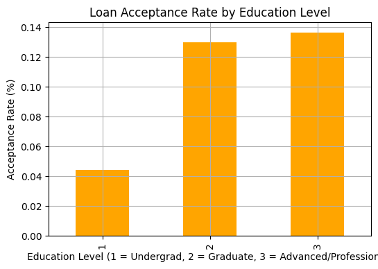

```python
# Personal Loan vs. Education

edu_loan_rate = df.groupby('Education')['Personal_Loan'].mean()

edu_loan_rate.plot(kind='bar', color='orange', figsize=(6,4))
plt.title('Loan Acceptance Rate by Education Level')
plt.xlabel('Education Level (1 = Undergrad, 2 = Graduate, 3 = Advanced/Professional)')
plt.ylabel('Acceptance Rate (%)')
plt.grid(True)
plt.show()
```

### Observations:

- Higher education levels (2 and 3) are associated with higher loan acceptance rates.
- Customers with only undergraduate education are less likely to accept loans.

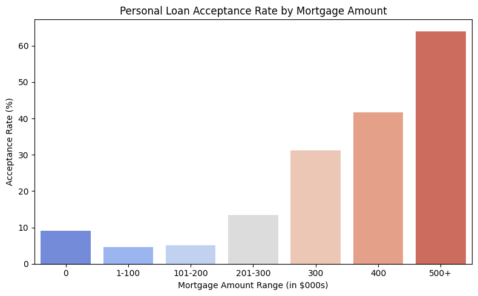

```python
df['Mortgage_Bin'] = pd.cut(df['Mortgage'], bins=[-1, 0, 100, 200, 300, 400, 500, df['Mortgage'].max()],
                            labels=['0', '1-100', '101-200', '201-300', '300', '400', '500+'])

mortgage_loan_rate = df.groupby('Mortgage_Bin')['Personal_Loan'].mean() * 100

plt.figure(figsize=(8, 5))
sns.barplot(x=mortgage_loan_rate.index, y=mortgage_loan_rate.values, palette='coolwarm')
plt.title("Personal Loan Acceptance Rate by Mortgage Amount")
plt.xlabel("Mortgage Amount Range (in $000s)")
plt.ylabel("Acceptance Rate (%)")
plt.tight_layout()
plt.show()
```

### Observations:

```python
df.drop(columns=['Mortgage_Bin', 'Age Group'], inplace=True)  # Clean up the DataFrame after plotting
```

## Data Preprocessing

- Missing value treatment
- Feature engineering (if needed)
- Outlier detection and treatment (if needed)
- Preparing data for modeling
- Any other preprocessing steps (if needed)

```python
# Missing values
missing_values = df.isnull().sum()
print("Missing values in each column: ")
print(missing_values)
```

```
Missing values in each column:
ID                    0
Age                   0
Experience            0
Income                0
ZIPCode               0
Family                0
CCAvg                 0
Education             0
Mortgage              0
Personal_Loan         0
Securities_Account    0
CD_Account            0
Online                0
CreditCard            0
dtype: int64
```

```python
df.shape
```

```
(5000, 14)
```

```python
def detect_outliers_iqr(data, column):
    Q1 = data[column].quantile(0.25)
    Q3 = data[column].quantile(0.75)
    IQR = Q3 - Q1
    lower = Q1 - 1.5 * IQR
    upper = Q3 + 1.5 * IQR
    outliers = data[(data[column] < lower) | (data[column] > upper)]
    print(f"{column}: {len(outliers)} outliers detected")
    return outliers

for col in ['Income', 'CCAvg', 'Mortgage']:
    detect_outliers_iqr(df, col)
```

```
Income: 96 outliers detected
CCAvg: 324 outliers detected
Mortgage: 291 outliers detected
```

```python
def cap_outliers_iqr(df, column):
    """
        This function caps the outliers in a specified column of a DataFrame using the IQR method.
        It calculates the upper bound based on the IQR and clips values above this bound.
    """
    Q1 = df[column].quantile(0.25)
    Q3 = df[column].quantile(0.75)
    IQR = Q3 - Q1
    upper_bound = Q3 + 1.5 * IQR
    df[column] = df[column].clip(upper=upper_bound)
    print(f"{column} Capped values above {upper_bound:.2f}")
    return df

for col in ['Income', 'CCAvg', 'Mortgage']:
    df = cap_outliers_iqr(df, col)
```

```
Income Capped values above 186.50
CCAvg Capped values above 5.20
Mortgage Capped values above 252.50
```

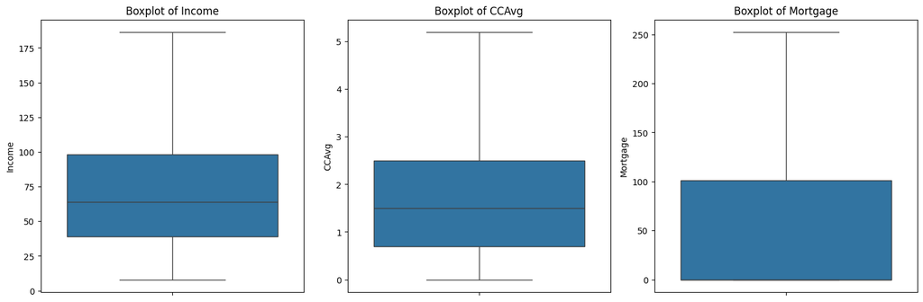

```python
plt.figure(figsize=(15, 5))

for i, col in enumerate(['Income', 'CCAvg', 'Mortgage'], 1):
    plt.subplot(1, 3, i)
    sns.boxplot(y=df[col])
    plt.title(f'Boxplot of {col}')

plt.tight_layout()
plt.show()
```

```python
# Recalculate IQR and upper bound for reference
Q1 = df[['Income', 'CCAvg', 'Mortgage']].quantile(0.25)
Q3 = df[['Income', 'CCAvg', 'Mortgage']].quantile(0.75)
IQR = Q3 - Q1
upper_bound = Q3 + 1.5 * IQR

# Count how many values are equal to the upper bound (i.e., capped)
capped_counts = {}
for col in ['Income', 'CCAvg', 'Mortgage']:
    capped_counts[col] = (df[col] == upper_bound[col]).sum()

print("Number of capped outliers:")
for col, count in capped_counts.items():
    print(f"{col}: {count}")
```

```
Number of capped outliers:
Income: 96
CCAvg: 340
Mortgage: 291
```

```python
# Train test split
from sklearn.model_selection import train_test_split

Y = df['Personal_Loan']
X = df.drop(columns=['Personal_Loan', 'ID', 'ZIPCode'])
X_train, X_test, y_train, y_test = train_test_split(X, Y, test_size=0.2)
```

## Model Building

### Model Evaluation Criterion

- **F1 Score**: Harmonic mean of precision and recall, useful in our case where we want to optimize both false positives and false negatives.

### Model Building

```python
from sklearn.tree import DecisionTreeClassifier
from sklearn.metrics import accuracy_score,f1_score

dt_classifier = DecisionTreeClassifier()
dt_classifier.fit(X_train, y_train)

y_pred = dt_classifier.predict(X_test)
```

```python
accuracy = accuracy_score(y_test, y_pred)
f1 = f1_score(y_test, y_pred)
```

```python
print("Decision Tree Performance on Test Set:")
print(f"Accuracy   : {accuracy:.4f}")
print(f"F1 Score  : {f1:.4f}")
```

```
Decision Tree Performance on Test Set:
Accuracy   : 0.9770
F1 Score  : 0.8832
```

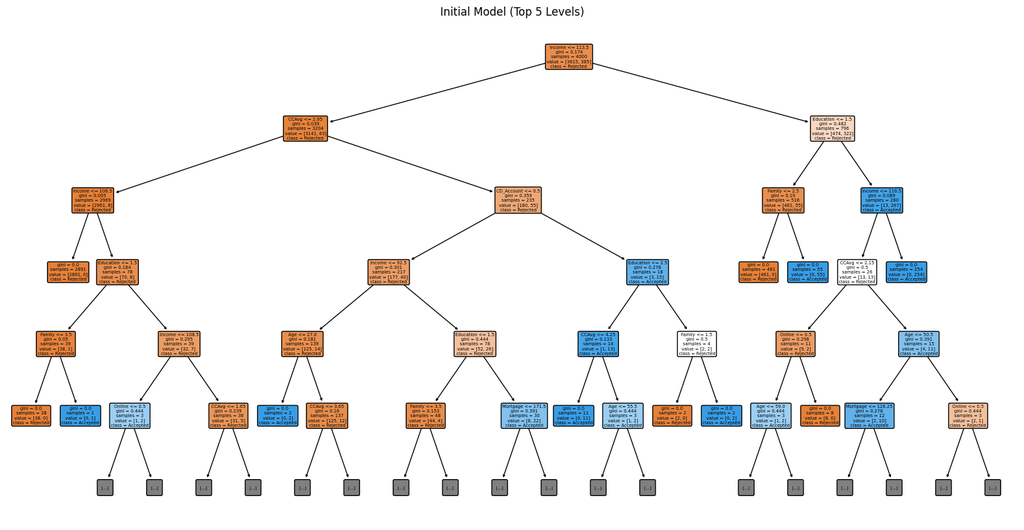

```python
from sklearn.tree import plot_tree

plt.figure(figsize=(20, 10))
plot_tree(
    dt_classifier,
    feature_names=X_train.columns,
    class_names=['Rejected', 'Accepted'],
    filled=True,
    rounded=True,
    max_depth=5  # I have limited the depth for better readabilitys
)
plt.title("Initial Model (Top 5 Levels)")
plt.show()
```

## Model Performance Improvement

For model performance improvement, we can consider the following techniques:

### Pre Pruning

- Setting the `max_depth` to prevent overfitting
- Limiting the `min_samples_leaf` to avoid splits on very small samples

```python
from sklearn.model_selection import GridSearchCV
tuned_dt = DecisionTreeClassifier()
param_grid = {
    'max_depth': [i for i in range(1, 11)],
    'min_samples_leaf': [i for i in range(1, 21)],
}

grid_search = GridSearchCV(
    estimator=tuned_dt,
    param_grid=param_grid,
    scoring='f1',
    n_jobs=5,
    cv=5,
)

grid_search.fit(X_train, y_train)

print("Best Parameters:", grid_search.best_params_)
```

```
Best Parameters: {'max_depth': 6, 'min_samples_leaf': 11}
```

```python
imporved_tree = grid_search.best_estimator_
y_pred_tuned = imporved_tree.predict(X_test)
```

```python
accuracy = accuracy_score(y_test, y_pred_tuned)
f1 = f1_score(y_test, y_pred_tuned)
```

```python
print("Tuned Decision Tree Performance on Test Set:")
print(f"Accuracy  : {accuracy:.4f}")
print(f"F1 Score  : {f1:.4f}")
```

```
Tuned Decision Tree Performance on Test Set:
Accuracy  : 0.9810
F1 Score  : 0.9005
```

#### Post Pruning

- Using cost complexity pruning to remove branches that have little importance

```python
path = dt_classifier.cost_complexity_pruning_path(X_train, y_train)
ccp_alphas = path.ccp_alphas
```

```python
from sklearn.tree import DecisionTreeClassifier

models = []
for alpha in ccp_alphas:
    dt = DecisionTreeClassifier(ccp_alpha=alpha)
    dt.fit(X_train, y_train)
    models.append(dt)
```

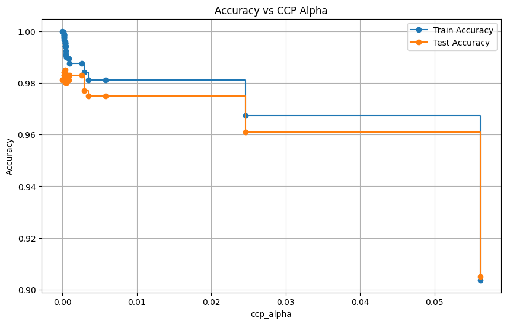

```python
train_scores = [model.score(X_train, y_train) for model in models]
test_scores = [model.score(X_test, y_test) for model in models]

plt.figure(figsize=(10,6))
plt.plot(ccp_alphas, train_scores, marker='o', label='Train Accuracy', drawstyle="steps-post")
plt.plot(ccp_alphas, test_scores, marker='o', label='Test Accuracy', drawstyle="steps-post")
plt.xlabel("ccp_alpha")
plt.ylabel("Accuracy")
plt.legend()
plt.title("Accuracy vs CCP Alpha")
plt.grid()
plt.show()
```

```python
import pandas as pd

results_df = pd.DataFrame({
    'alpha': ccp_alphas,
    'train_accuracy': train_scores,
    'test_accuracy': test_scores,
})

sorted_df = results_df.sort_values(by='test_accuracy', ascending=False)
print(sorted_df.head())
```

```
       alpha  train_accuracy  test_accuracy
10  0.000333         0.99575          0.985
3   0.000227         0.99875          0.984
6   0.000235         0.99850          0.984
13  0.000333         0.99525          0.984
15  0.000339         0.99525          0.983
```

```python
post_pruned_model = DecisionTreeClassifier(ccp_alpha=sorted_df['alpha'].iloc[0])
post_pruned_model.fit(X_train, y_train)
```

```
DecisionTreeClassifier(ccp_alpha=0.0003333333333333333)
```

```python
post_prune_pred = post_pruned_model.predict(X_test)
accuracy = accuracy_score(y_test, post_prune_pred)
f1 = f1_score(y_test, post_prune_pred)
```

```python
print("Post Pruned Model Performance:")
print(f"Accuracy  : {accuracy:.4f}")
print(f"F1 Score  : {f1:.4f}")
```

```
Post Pruned Model Performance:
Accuracy  : 0.9830
F1 Score  : 0.9110
```

## Model Performance Comparison and Final Model Selection

```python
# Comparing the base model vs best tuned model
from sklearn.metrics import classification_report

print("Base Decision Tree Performance on Test Set:")
print(classification_report(y_test, y_pred))

print("Pre-Pruned Decision Tree Performance on Test Set:")
print(classification_report(y_test, y_pred_tuned))

print("Post Pruned Model Performance on Test Set:")
print(classification_report(y_test, post_prune_pred))
```

```
Base Decision Tree Performance on Test Set:
              precision    recall  f1-score   support

           0       0.99      0.98      0.99       905
           1       0.85      0.92      0.88        95

    accuracy                           0.98      1000
   macro avg       0.92      0.95      0.94      1000
weighted avg       0.98      0.98      0.98      1000

Pre-Pruned Decision Tree Performance on Test Set:
              precision    recall  f1-score   support

           0       0.99      0.99      0.99       905
           1       0.90      0.91      0.90        95

    accuracy                           0.98      1000
   macro avg       0.94      0.95      0.95      1000
weighted avg       0.98      0.98      0.98      1000

Post Pruned Model Performance on Test Set:
              precision    recall  f1-score   support

           0       0.99      0.99      0.99       905
           1       0.91      0.92      0.91        95

    accuracy                           0.98      1000
   macro avg       0.95      0.95      0.95      1000
weighted avg       0.98      0.98      0.98      1000
```

We will select the post pruned model as it has better f1 score and accuracy as compared to the the other two models. The tuned model also has a better balance between precision and recall, making it more suitable for our use case where we want to minimize false positives and false negatives.

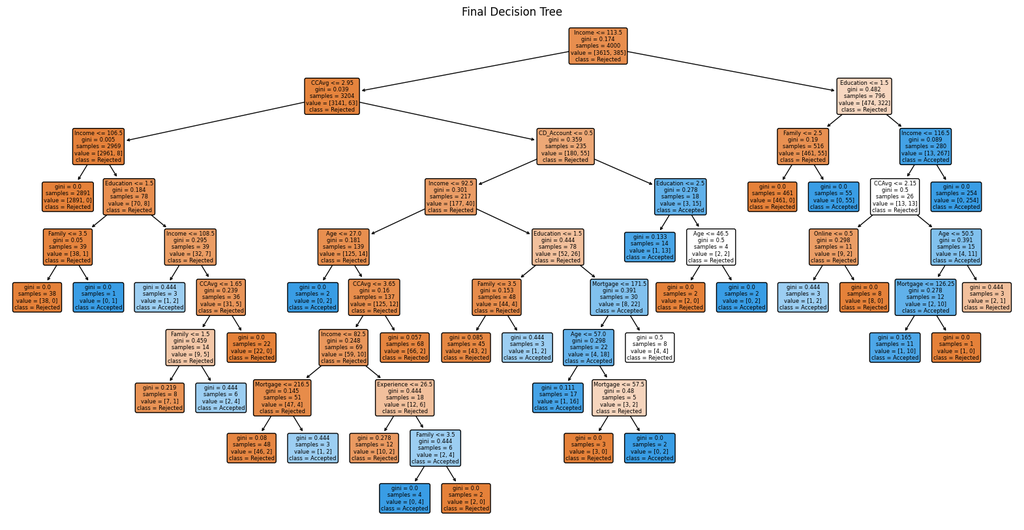

```python
plt.figure(figsize=(20, 10))
plot_tree(
    post_pruned_model,  # Post pruned Model
    feature_names=X_train.columns,
    class_names=['Rejected', 'Accepted'],
    filled=True,
    rounded=True,
)
plt.title("Final Decision Tree")
plt.show()
```

## Actionable Insights and Business Recommendations

- What recommedations would you suggest to the bank?
1. **Target High-Income Customers**: Customers with higher annual incomes show a significantly greater likelihood of accepting personal loans. The bank should prioritize marketing campaigns towards this customer segment to maximize conversion rates.
2. **Focus on Customers with Higher Credit Card Spending (CCAvg)**: There is a strong positive correlation between average monthly credit card spending and personal loan acceptance. Customers with higher CCAvg are more likely to take personal loans, making them an attractive target group.
3. **Leverage Education Level**: Customers with graduate or advanced/professional degrees have a much higher acceptance rate for personal loans compared to undergraduates. Tailoring loan products and marketing messages to appeal to these education segments can improve campaign effectiveness.
4. **Consider Mortgage Holders**: Loan acceptance rates increase with higher mortgage amounts. Customers with substantial mortgages may have greater financial needs and can be targeted for cross-selling personal loans.
5. **Balanced Approach to Credit Card Holders**: Since credit card ownership does not significantly influence loan acceptance, campaigns should not exclude non-credit card holders.
6. **Personalized Offers**: Use the predictive model to score existing liability customers and identify those with the highest probability of accepting a loan. Personalized offers can then be sent to these high-propensity customers.

By implementing these recommendations, AllLife Bank can improve the efficiency of its marketing campaigns, increase personal loan uptake, and drive higher revenue from its existing customer base.